# NAA10 het liver

Andrew Garcia

2023-01-28

# liver data

## stats and summary stats

```r
liver <- read.csv("https://docs.google.com/spreadsheets/d/e/2PACX-1vTLmgeuvv-9LZ7wmye300YHyft6hknpdF9volz23xEZENyhRra1DKxfLPytpTQnRd7s7LN2CgI5ZGsu/pub?gid=0&single=true&output=csv", header = T)

head(liver)
```

```
##   ID Name         Genotype Replicate       MW    Signal  Total Background Area
## 1  6 5218        Naa10 +/+         C 33.37778 28348.992 368976   660.1299  516
## 2  5 5217 Naa10 +/- or -/+         C 33.67953 24118.115 380982   653.5969  546
## 3  4 5115        Naa10 +/+         C 30.40876 47526.994 371359   642.5238  504
## 4  3 5112 Naa10 +/- or -/+         C 29.53488  9015.859 360184   643.1651  546
## 5  2 4942 Naa10 +/- or -/+         C 33.07692 11360.371 368900   654.8345  546
## 6  1 4924        Naa10 +/+         C 31.29032 32166.884 449310   651.7861  640
##   Normalized.Signal Amount..µg.      SNR Avg..Norm..Signal Avg..SNR Std..Dev.
## 1         40557.353          20 3.183774          20901.57 2.151075  17146.34
## 2         27662.596          20 3.735191          42973.67 5.295918  15106.39
## 3         57866.704          20 8.421608          42973.67 5.295918  15106.39
## 4          9015.859          20 1.451222          20901.57 2.151075  17146.34
## 5         13131.490          20 1.818230          20901.57 2.151075  17146.34
## 6         43391.723          20 3.730957          42973.67 5.295918  15106.39
##      X..CV   Type
## 1 82.03376 Sample
## 2 35.15267 Sample
## 3 35.15267 Sample
## 4 82.03376 Sample
## 5 82.03376 Sample
## 6 35.15267 Sample
```

```r
liver$ID <-as.factor(liver$ID)
liver$Name <- as.factor(liver$Name)
liver$Genotype <- as.factor(liver$Genotype)
liver$Replicate <- as.factor (liver$Replicate)

head(liver)
```

```
##   ID Name         Genotype Replicate       MW    Signal  Total Background Area
## 1  6 5218        Naa10 +/+         C 33.37778 28348.992 368976   660.1299  516
## 2  5 5217 Naa10 +/- or -/+         C 33.67953 24118.115 380982   653.5969  546
## 3  4 5115        Naa10 +/+         C 30.40876 47526.994 371359   642.5238  504
## 4  3 5112 Naa10 +/- or -/+         C 29.53488  9015.859 360184   643.1651  546
## 5  2 4942 Naa10 +/- or -/+         C 33.07692 11360.371 368900   654.8345  546
## 6  1 4924        Naa10 +/+         C 31.29032 32166.884 449310   651.7861  640
##   Normalized.Signal Amount..µg.      SNR Avg..Norm..Signal Avg..SNR Std..Dev.
## 1         40557.353          20 3.183774          20901.57 2.151075  17146.34
## 2         27662.596          20 3.735191          42973.67 5.295918  15106.39
## 3         57866.704          20 8.421608          42973.67 5.295918  15106.39
## 4          9015.859          20 1.451222          20901.57 2.151075  17146.34
## 5         13131.490          20 1.818230          20901.57 2.151075  17146.34
## 6         43391.723          20 3.730957          42973.67 5.295918  15106.39
##      X..CV   Type
## 1 82.03376 Sample
## 2 35.15267 Sample
## 3 35.15267 Sample
## 4 82.03376 Sample
## 5 82.03376 Sample
## 6 35.15267 Sample
```

```r
install.packages("Rmisc",repos = "http://cran.us.r-project.org")
##Summary statistics for Normalized NAA10 signal, grouped by genotype and technical replicate
##Replicate grouping pertains to replicate blot grouping

library(Rmisc)
liver_sum <- summarySE(liver, measurevar="Normalized.Signal", groupvars=c("Genotype","Replicate"))

liver_sum
```

```
##           Genotype Replicate N Normalized.Signal        sd        se       ci
## 1 Naa10 +/- or -/+         A 3          19431.81 13186.929  7613.477 32758.15
## 2 Naa10 +/- or -/+         B 3          49014.99 35812.740 20676.495 88963.78
## 3 Naa10 +/- or -/+         C 3          16603.31  9796.192  5655.834 24335.09
## 4        Naa10 +/+         A 3          21684.31 13541.893  7818.416 33639.93
## 5        Naa10 +/+         B 3          87620.31 11921.835  6883.075 29615.48
## 6        Naa10 +/+         C 3          47271.93  9284.147  5360.205 23063.10
```

```r
##Summary statistics for Normalized NAA10 signal, grouped by genotype and technical replicate
##Replicate grouping pertains to replicate blot grouping

library(Rmisc)
liver_sum1 <- summarySE(liver, measurevar="Normalized.Signal", groupvars=c("Genotype"))

liver_sum1
```

```
##           Genotype N Normalized.Signal       sd        se       ci
## 1 Naa10 +/- or -/+ 9          28350.04 25096.08  8365.361 19290.56
## 2        Naa10 +/+ 9          52192.18 30523.94 10174.648 23462.78
```

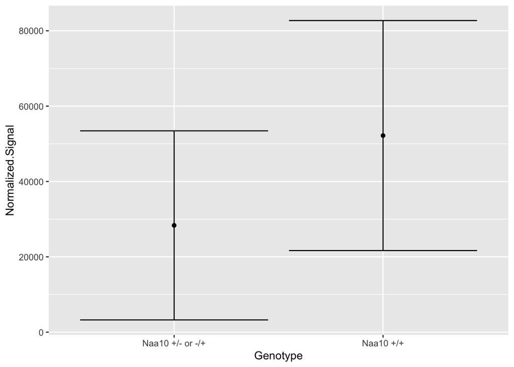

```r
install.packages("ggplot2", repos = "http://cran.us.r-project.org")
#group means plus standard deviations come from summary stat dataframe
#essentially looking to plot this onto the individual data plot

library(ggplot2)
ggplot(liver_sum1, aes(x = Genotype, y = Normalized.Signal))+
  geom_point()+
  geom_errorbar(aes(ymin = Normalized.Signal - sd,
                ymax = Normalized.Signal + sd))
```

## plot with points and group means

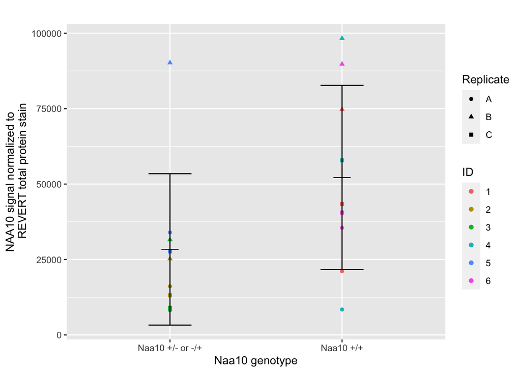

```r
#ggplot(heart) plots Normalized.Signal as a function of Genotype
#geom_point plots individual observations on this plot
#individual data points may need to be jittered
#geom_errorbar points to my group means df heart_sum1 and the bounds of the mean+/- standard error bar
#mean is plotted via stat_summary

ggplot(liver,aes(x = Genotype,
                 y = Normalized.Signal))+
  geom_point(aes(color = ID,
                 shape = Replicate),
             alpha = 1)+
  stat_summary(fun= mean, geom="point",
               shape=3, size=5, color="black", fill="black")+
  geom_errorbar(data = liver_sum1,
                aes(ymin = Normalized.Signal-sd,
                    ymax = Normalized.Signal+sd,
                    width = 0.25))+
  xlab("Naa10 genotype")+
  ylab("NAA10 signal normalized to
       REVERT total protein stain")+
  ggtitle("")
```

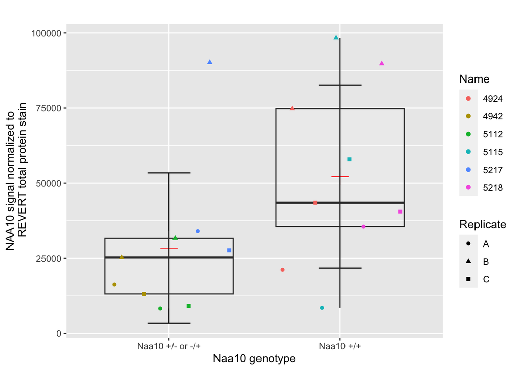

```r
ggplot(liver,aes(x = Genotype,
                 y = Normalized.Signal))+
  stat_summary(fun= mean, geom="point",
               shape=3, size=5, color="red", fill="black")+
  geom_errorbar(data = liver_sum1,
                aes(ymin = Normalized.Signal-sd,
                    ymax = Normalized.Signal+sd,
                    width = 0.25))+
    geom_boxplot(outlier.shape = NA,
               alpha = 0.1)+
  geom_point(aes(color = Name,
                 shape = Replicate),
             alpha = 1,
                 position = position_jitterdodge())+
  xlab("Naa10 genotype")+
  ylab("NAA10 signal normalized to
       REVERT total protein stain")+
  ggtitle("")
```

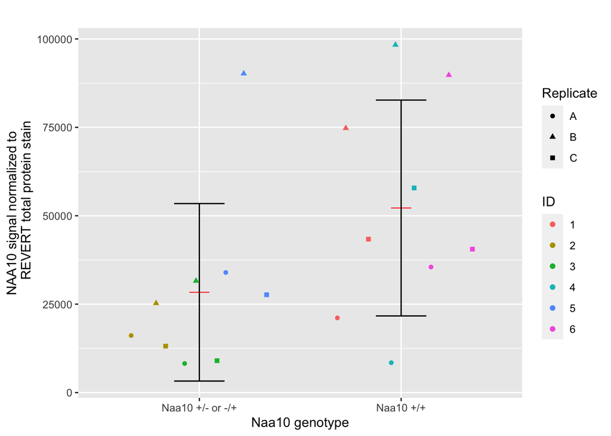

```r
ggplot(liver,aes(x = Genotype,
                 y = Normalized.Signal))+
  stat_summary(fun= mean, geom="point",
               shape=3, size=5, color="red", fill="black")+
  geom_errorbar(data = liver_sum1,
                aes(ymin = Normalized.Signal-sd,
                    ymax = Normalized.Signal+sd,
                    width = 0.25))+
  geom_point(aes(color = ID,
                 shape = Replicate),
             alpha = 1,
                 position = position_jitterdodge())+
  xlab("Naa10 genotype")+
  ylab("NAA10 signal normalized to
       REVERT total protein stain")+
  ggtitle("")
```

## jittered plot

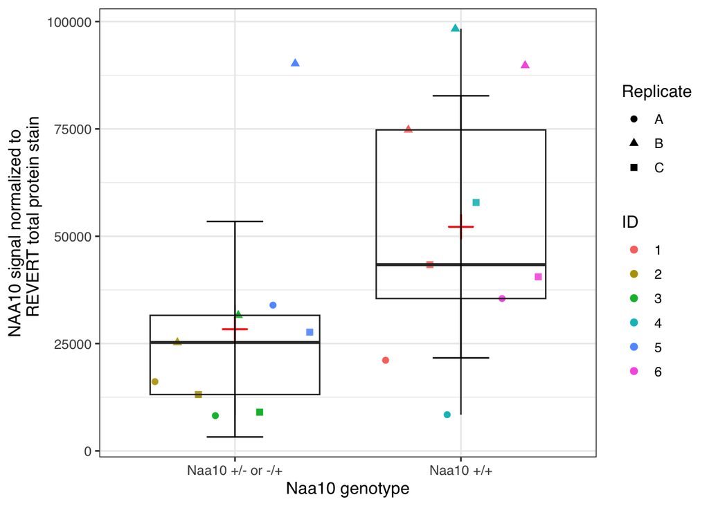

```r
#same plot as above, but with jittered points
library(ggplot2)
liver.fig <- ggplot(liver,aes(x = Genotype,
                 y = Normalized.Signal))+
  geom_point(aes(color = ID,
                 shape = Replicate),
             alpha = 1,
             size = 2,
                 position = position_jitterdodge())+
  geom_boxplot(outlier.shape = NA,
               alpha = 0.1)+
  stat_summary(fun= mean, geom="point",
               shape=3, size=5,stroke = 1,color="red", fill="black")+
  geom_errorbar(data = liver_sum1,
                aes(ymin = Normalized.Signal-sd,
                    ymax = Normalized.Signal+sd,
                    width = 0.25))+
  xlab("Naa10 genotype")+
  ylab("NAA10 signal normalized to
       REVERT total protein stain")+
  theme_bw(base_size = 12, base_family = "Helvetica")

liver.fig
```

# hypothesis testing

## parametric

### two-sample t-test

null hypothesis: there is no mean difference in NAA10 signal between Naa10 female genotypes

Alternative: there is a difference in NAA10 signal between Naa10 female genotypes

```r
##Unpaired t-test of NAA10 signal grouped by Genotype
t.test(liver$Normalized.Signal~liver$Genotype,
       paired = F,
       var.equal = F)
```

```
##
##  Welch Two Sample t-test
##
## data:  liver$Normalized.Signal by liver$Genotype
## t = -1.8101, df = 15.423, p-value = 0.08981
## alternative hypothesis: true difference in means between group Naa10 +/- or -/+ and group Naa10 +/+ is not equal to 0
## 95 percent confidence interval:
##  -51850.699   4166.407
## sample estimates:
## mean in group Naa10 +/- or -/+        mean in group Naa10 +/+
##                       28350.04                       52192.18
```

I fail to reject the null hypothesis

### differences between replicates

Null hypothesis: there is no difference in NAA10 signal of individual hearts on replicate blots Alternative hypothesis: there is a difference in NAA10 signal of individual hearts on replicate blots

```r
install.packages("car",repos = "http://cran.us.r-project.org")
```

[output not shown]

```r
library(car)
liver.aov <- lm(Normalized.Signal~Replicate, liver)
summary(liver.aov)
```

```
##
## Call:
## lm(formula = Normalized.Signal ~ Replicate, data = liver)
##
## Residuals:
##    Min     1Q Median     3Q    Max
## -43059 -12291   3502  14559  30001
##
## Coefficients:
##             Estimate Std. Error t value Pr(>|t|)
## (Intercept)    20558       9179   2.240  0.04068 *
## ReplicateB     47760      12980   3.679  0.00223 **
## ReplicateC     11380      12980   0.877  0.39449
## ---
## Signif. codes:  0 '***' 0.001 '**' 0.01 '*' 0.05 '.' 0.1 ' ' 1
##
## Residual standard error: 22480 on 15 degrees of freedom
## Multiple R-squared:  0.4962, Adjusted R-squared:  0.429
## F-statistic: 7.387 on 2 and 15 DF,  p-value: 0.005847
```

```r
Anova(liver.aov,type = "III")
```

```
## Anova Table (Type III tests)
##
## Response: Normalized.Signal
##                 Sum Sq Df F value   Pr(>F)
## (Intercept) 2535803337  1  5.0166 0.040679 *
## Replicate   7467957260  2  7.3869 0.005847 **
## Residuals   7582254906 15
## ---
## Signif. codes:  0 '***' 0.001 '**' 0.01 '*' 0.05 '.' 0.1 ' ' 1
```

# #non-parametric testing

### NAA10 signal and Genotype

I have a big outlier in each genotype, so I will perform non-parametric hypothesis tests.

```r
#Wilcox test instead of Welch's test
wilcox.test(Normalized.Signal~Genotype,liver)
```

```
##
##  Wilcoxon rank sum exact test
##
## data:  Normalized.Signal by Genotype
## W = 19, p-value = 0.06253
## alternative hypothesis: true location shift is not equal to 0
```

p = 0.06253; I fail to reject the null hypothesis.

### Does replicate blot drive differences in NAA10 signal

```r
kruskal.test(Normalized.Signal~Replicate,liver)
```

```
##
##  Kruskal-Wallis rank sum test
##
## data:  Normalized.Signal by Replicate
## Kruskal-Wallis chi-squared = 6.538, df = 2, p-value = 0.03804
```

```r
install.packages("coin",repos = "http://cran.us.r-project.org")
library(coin)
mood_test(Normalized.Signal~Genotype,liver)
```

```
##
##  Asymptotic Two-Sample Mood Test
##
## data:  Normalized.Signal by Genotype (Naa10 +/- or -/+, Naa10 +/+)
## Z = -0.22942, p-value = 0.8185
## alternative hypothesis: true ratio of scales is not equal to 1
```

# earlier dataset with C57 females as inbred strain controls

```r
liver_c57 <- read.csv("https://docs.google.com/spreadsheets/d/e/2PACX-1vSOj04z27d0l76VXIjCAsvYw_0hn0_JUnmxJmXN6R0kuVZA3RytBDzfvBUv5WcNUg/pub?gid=788568614&single=true&output=csv",header = T)

head(liver_c57)
```

```
##      Name  Genotype Replicate       MW   Signal  Total Background Area
## 1    3966 Naa10 -/+         2 27.38863 24587.19 366695   356.3623  960
## 2    4344 Naa10 -/+         2 27.87806  9376.70 156940   361.6747  408
## 3    4290 Naa10 -/+         2 28.61973 13558.03 288747   362.0908  760
## 4 C57-5-3 Naa10 +/+         2 29.11928 24526.16 221996   361.6664  546
## 5 C57-3-1 Naa10 +/+         2 29.37060 18199.76 201570   353.9966  518
## 6 C57-3-2 Naa10 +/+         2 30.13083 15284.35 253929   355.1260  672
##   Normalized.Signal Concentration..µg.      SNR Genotype.1 Avg..Norm..Signal
## 1          24587.19                 20 2.827657      KO/WT          25495.61
## 2          18137.84                 20 2.227979      KO/WT          25495.61
## 3          33761.79                 20 1.593014      KO/WT          25495.61
## 4          46677.18                 20 4.441021      WT/WT          42682.07
## 5          50588.09                 20 4.468261      WT/WT          42682.07
## 6          30780.95                 20 2.957676      WT/WT          42682.07
##   Avg..SNR Std..Dev.    X..CV   Type
## 1 2.216217  7851.489 30.79546 Sample
## 2 2.216217  7851.489 30.79546 Sample
## 3 2.216217  7851.489 30.79546 Sample
## 4 3.955653 10490.533 24.57831 Sample
## 5 3.955653 10490.533 24.57831 Sample
## 6 3.955653 10490.533 24.57831 Sample
```

```r
liver_c57$Name <- as.factor(liver_c57$Name)
liver_c57$Genotype <- as.factor(liver_c57$Genotype)
liver_c57$Replicate <- as.factor (liver_c57$Replicate)

head(liver_c57)
```

```
##      Name  Genotype Replicate       MW   Signal  Total Background Area
## 1    3966 Naa10 -/+         2 27.38863 24587.19 366695   356.3623  960
## 2    4344 Naa10 -/+         2 27.87806  9376.70 156940   361.6747  408
## 3    4290 Naa10 -/+         2 28.61973 13558.03 288747   362.0908  760
## 4 C57-5-3 Naa10 +/+         2 29.11928 24526.16 221996   361.6664  546
## 5 C57-3-1 Naa10 +/+         2 29.37060 18199.76 201570   353.9966  518
## 6 C57-3-2 Naa10 +/+         2 30.13083 15284.35 253929   355.1260  672
##   Normalized.Signal Concentration..µg.      SNR Genotype.1 Avg..Norm..Signal
## 1          24587.19                 20 2.827657      KO/WT          25495.61
## 2          18137.84                 20 2.227979      KO/WT          25495.61
## 3          33761.79                 20 1.593014      KO/WT          25495.61
## 4          46677.18                 20 4.441021      WT/WT          42682.07
## 5          50588.09                 20 4.468261      WT/WT          42682.07
## 6          30780.95                 20 2.957676      WT/WT          42682.07
##   Avg..SNR Std..Dev.    X..CV   Type
## 1 2.216217  7851.489 30.79546 Sample
## 2 2.216217  7851.489 30.79546 Sample
## 3 2.216217  7851.489 30.79546 Sample
## 4 3.955653 10490.533 24.57831 Sample
## 5 3.955653 10490.533 24.57831 Sample
## 6 3.955653 10490.533 24.57831 Sample
```

```r
library(Rmisc)
liver_c57_sum <- summarySE(liver_c57, measurevar="Normalized.Signal", groupvars=c("Genotype"))

liver_c57_sum
```

```
##    Genotype N Normalized.Signal       sd       se       ci
## 1 Naa10 -/+ 6          16334.36 11523.77 4704.558 12093.45
## 2 Naa10 +/+ 6          29749.10 15697.81 6408.605 16473.84
```

```r
library(ggplot2)
```

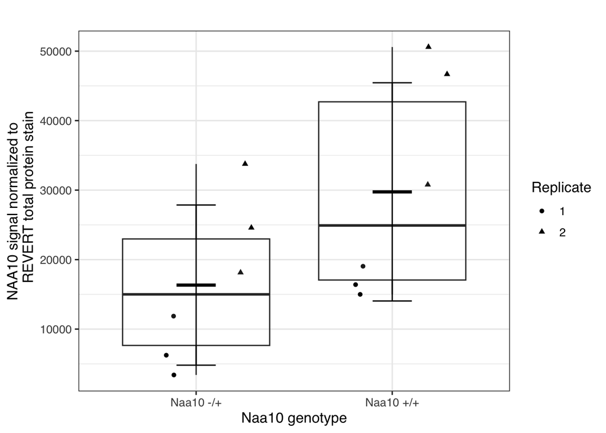

```r
library(ggplot2)

c57_fig <- ggplot(liver_c57,aes(x = Genotype,
                 y = Normalized.Signal))+
  geom_point(aes(shape = Replicate),
             alpha = 1.0,
             position = position_jitterdodge())+
  geom_boxplot(outlier.shape = NA,
               alpha = 0.1)+
  stat_summary(fun = mean, color = "black",
               position = position_dodge(0.75),width = 0.2,
             geom = "crossbar",
             show.legend = FALSE)+
  geom_errorbar(data = liver_c57_sum,
                aes(ymin = Normalized.Signal-sd,
                    ymax = Normalized.Signal+sd,
                    width = 0.2))+
  xlab("Naa10 genotype")+
  ylab("NAA10 signal normalized to
       REVERT total protein stain")+
  ggtitle("")+theme_bw(base_size =12, base_family = "Helvetica")

c57_fig
```

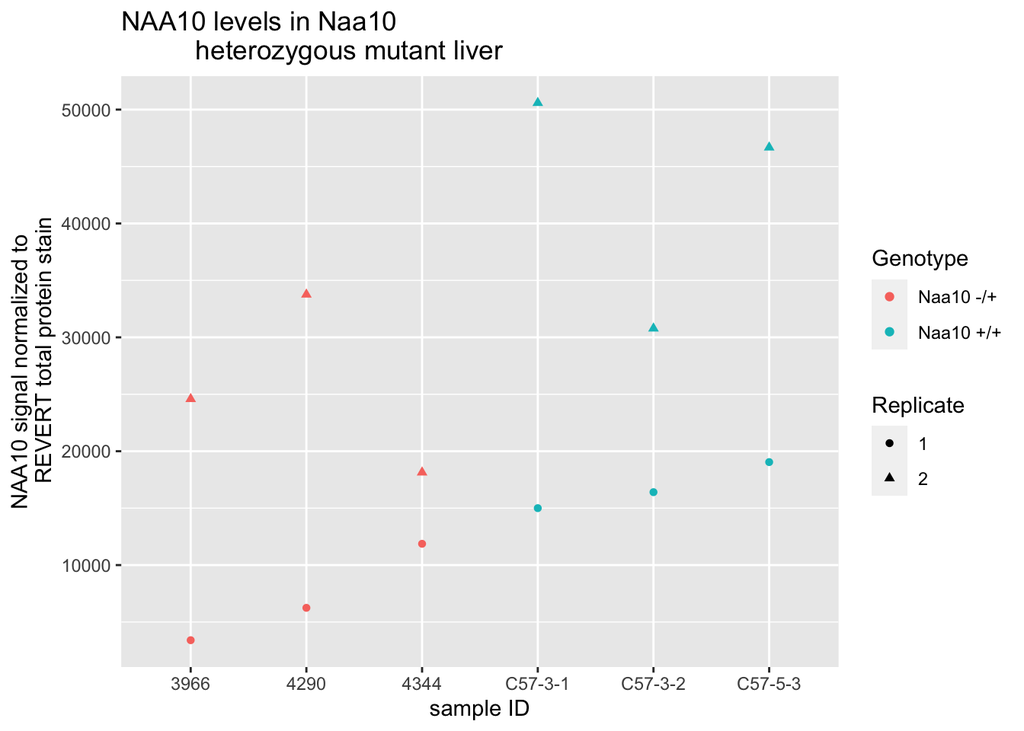

```r
##Plotted by biological replicate

ggplot(liver_c57, aes(x = Name,
                  y = Normalized.Signal,
                  shape = Replicate,
                  color = Genotype))+
         geom_point()+
  xlab("sample ID")+
  ylab("NAA10 signal normalized to
       REVERT total protein stain")+
   ggtitle("NAA10 levels in Naa10
          heterozygous mutant liver")
```

```r
##verify genotypes of 4942 and 4924 (may be flipped in source data)
```

```r
t.test(liver_c57$Normalized.Signal~liver_c57$Genotype,
       paired = F,
       var.equal = F)
```

```
##
##  Welch Two Sample t-test
##
## data:  liver_c57$Normalized.Signal by liver_c57$Genotype
## t = -1.6874, df = 9.1762, p-value = 0.1252
## alternative hypothesis: true difference in means between group Naa10 -/+ and group Naa10 +/+ is not equal to 0
## 95 percent confidence interval:
##  -31346.475   4516.984
## sample estimates:
## mean in group Naa10 -/+ mean in group Naa10 +/+
##                16334.36                29749.10
```

2-sample t-test indicates there is no significant difference in NAA10 signal between genotypes; however, the means are non-equal.

```r
t.test(liver_c57$Normalized.Signal~liver_c57$Replicate,
       paired = T,
       var.equal = F)
```

```
##
##  Paired t-test
##
## data:  liver_c57$Normalized.Signal by liver_c57$Replicate
## t = -5.7446, df = 5, p-value = 0.002241
## alternative hypothesis: true mean difference is not equal to 0
## 95 percent confidence interval:
##  -31980.97 -12207.46
## sample estimates:
## mean difference
##       -22094.22
```

Paired t-test indicates there is a significant difference between biological replicates on replicate blots. First I will analyze based on Replicate. Paired t-test already indicates there are differences between replicates so I don’t necessarily need to do post-hoc testing. However, I will use a Tukey-Kramer test.

If I include more variables in my model (Replicate, Genotype) that drive changes in Normalized.Signal, I can use post-hoc testing to specify which biological replicates differ.

For later reference: just re-run the samples again (ideally from new aliquots).

However, the samples for this dataset have been used up.

```r
liver_c57_aov <- aov(Normalized.Signal~Replicate,liver_c57)

summary(liver_c57_aov)
```

```
##             Df    Sum Sq   Mean Sq F value  Pr(>F)
## Replicate    1 1.464e+09 1.464e+09   15.07 0.00305 **
## Residuals   10 9.715e+08 9.715e+07
## ---
## Signif. codes:  0 '***' 0.001 '**' 0.01 '*' 0.05 '.' 0.1 ' ' 1
```

```r
TukeyHSD(liver_c57_aov, conf.level = 0.95)
```

```
##   Tukey multiple comparisons of means
##     95% family-wise confidence level
##
## Fit: aov(formula = Normalized.Signal ~ Replicate, data = liver_c57)
##
## $Replicate
##         diff      lwr      upr     p adj
## 2-1 22094.22 9414.723 34773.71 0.0030462
```